The format of this lab follows the same format as the previous ones. Your goal is to predict the value of the third column (which will be missing on the test set) using the techniques we have learned so far.

# Set-up

Read in the following libraries and to load the metadata:

```r
library(readr)
library(dplyr)
```

```r
library(ggplot2)
library(viridis)
library(stringi)
library(tokenizers)
library(smodels)
library(keras)
library(Matrix)
library(methods)

imdb <- read_csv("https://statsmaths.github.io/ml_data/imdb.csv")
```

# Lab 22

```r
words <- tokenize_words(imdb$text)
vocab <- top_n(count(data_frame(word=unlist(words)), word), n=5000)$word
id <- lapply(words, function(v) match(v, vocab))
id <- lapply(id, function(v) v[!is.na(v)])

X <- pad_sequences(id, maxlen = 100)
```

We then construct our training data sets.

```r
y <- imdb$class

X_train <- X[imdb$train_id == "train",]
y_train <- to_categorical(y[imdb$train_id == "train"], num_classes = 2)
```

Finally, I display the final model I used in the block of code below. I also list out the changes I made along the way and potential reasons for those changes. - Most importantly, I reduced my learning rate as it significantly reduced the amount my training and validation set accuracy difference (decreased overfitting substantially).  
- Reducing the dropout rate made a few % difference in my final model. - Reducing the pooling size slightly helped improve my accuracy as well - I also decided to increase the number of total filters in my convolutional layer

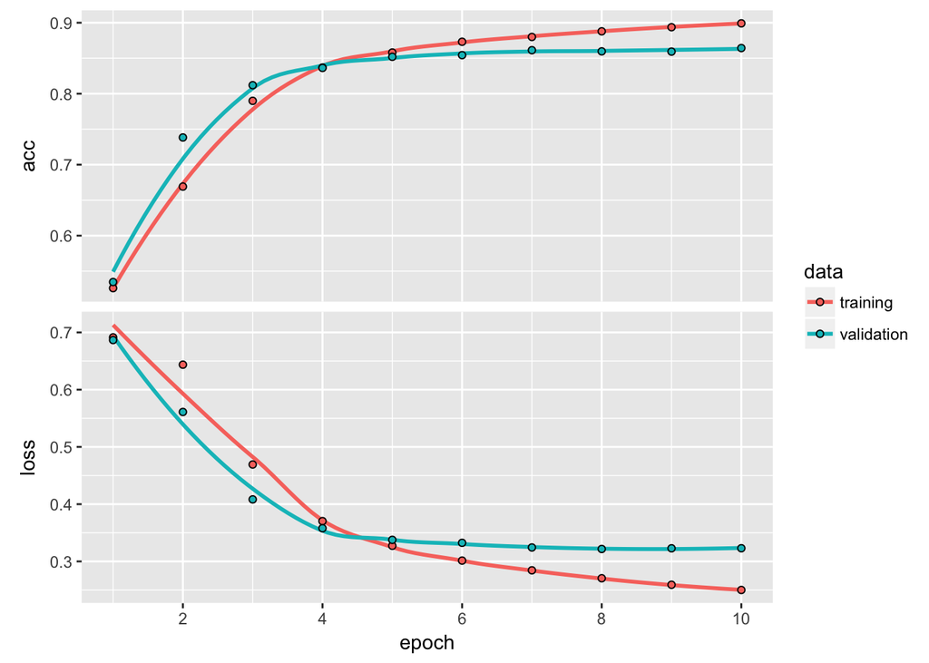

```r
model <- keras_model_sequential()
model %>%
    layer_embedding(
      input_dim = length(vocab) + 1,
      output_dim = 50,
      input_length = ncol(X)
    ) %>%

    layer_conv_1d(filters = 64, kernel_size = c(4)) %>%
    layer_max_pooling_1d(pool_size = 4L) %>%
    layer_dropout(rate = 0.12) %>%

    layer_flatten() %>%
    layer_dense(128) %>%
    layer_activation("relu") %>%
    layer_dropout(rate = 0.12) %>%

    layer_dense(ncol(y_train)) %>%
    layer_activation("softmax")

model %>% compile(
  loss = "binary_crossentropy",
  optimizer = optimizer_rmsprop(lr = 0.00005),
  metrics = "accuracy"

)

history <- model %>% fit(X_train, y_train, batch_size = 32,
                         epochs = 10,
                         validation_split = 0.1)
plot(history)
```

Finally, we take a look at how well the training and validations sets did

```r
y_pred <- predict_classes(model, X)
tapply(y_pred == imdb$class, imdb$train_id, mean)
```

```
##   test  train  valid
##     NA 0.9026 0.8615
```

# Submission

The code below assumes that you have added a prediction named `class_pred` to every row of the dataset.

```r
imdb$class_pred <- y_pred
submit <- select(imdb, obs_id, class_pred)
write_csv(submit, "class22_submit.csv")
```

Now, upload this file (ends with “.Rmd”), the HTML output (ends with “.nb.html” or “.html”), and the csv file to GitHub.